# ¿Puede un estudio honesto llegar a una conclusión falsa?

Una pregunta del semillero MetaCiencia

Juan David Leongómez

# **¿Puede un estudio honesto llegar a una conclusión falsa?**

👉 Haz clic, usa las flechas, o desliza para descubrir la respuesta

## Piensa en alguien honesto

Cuidadoso. Jamás inventaría un dato.

Aun así, su estudio puede llegar a una conclusión falsa.

## Imagina que la hipótesis es…

que el rey tiene buena puntería con el arco

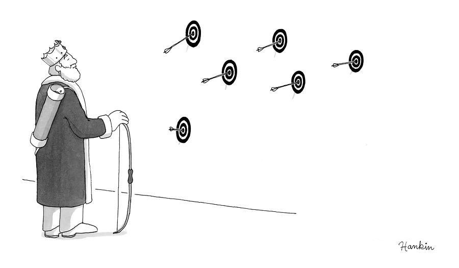

Si hay blancos fijos, ya puestos, y les da a todos en el centro…

eso es evidencia fuerte de que tiene puntería

## Pero…

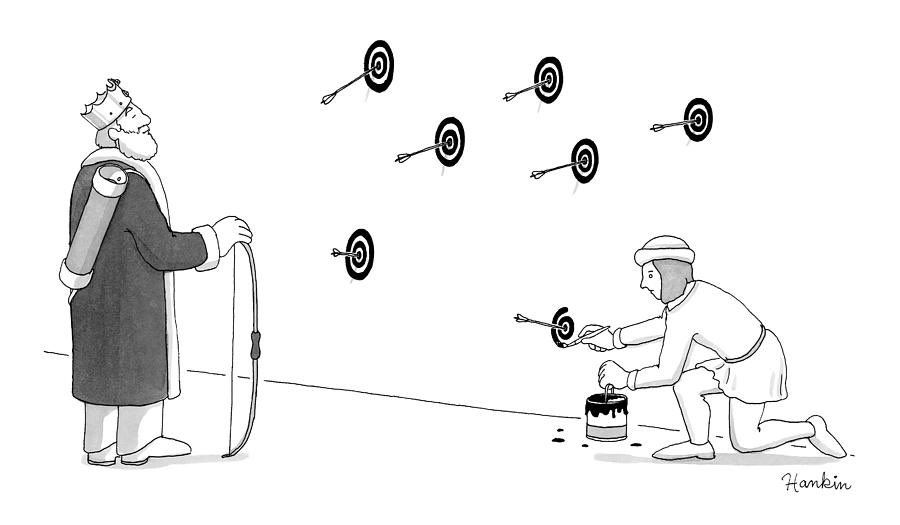

¿Y si dispara primero, a donde sea,

y los blancos se pintan **después**, alrededor de las flechas?

Eso no es evidencia de nada

A eso lo llamamos **HARKing**: inventar la hipótesis después de conocer el resultado

## La misma situación, con datos

Elegir qué variables analizar, qué datos “raros” excluir, cuándo detenerse…

**después** de ver los datos, es equivalente a pintar el blanco alrededor de la flecha

## El problema no es “mala intención”

sino un sistema que premia *encontrar algo*, sin preguntarse si el blanco ya estaba puesto antes de disparar

## El camino tradicional

SIN PLAN REGISTRADO

Diseñar el estudio y  
recoger datos

→

Analizar datos

con flexibilidad

→

Escribir el artículo

se puede reformular la hipótesis

→

Enviar a una revista

→

Revisión por pares  
↻ a menudo varias rondas

↓

¿Aceptado?

Depende, en parte, de si los resultados "se ven bien" — la semilla del sesgo de publicación

Al momento de la revisión por pares, el resultado ya existe

## El Reporte Registrado

ETAPA 1

Planear el estudio y  
escribir Intro/Método

→

Enviar

→

Revisión por pares  
↻ a menudo varias rondas

→

Refinar el método  
con los revisores

↓

Aceptación en Principio (IPA)

Plan sólido → la revista se compromete a publicar

↓

ETAPA 2

Recoger datos y  
escribir Resultados/Discusión

→

Enviar Etapa 2

→

Revisión  
(típicamente más ligera)

↓

Publicado

Sin importar los resultados

El blanco se fija antes de disparar

El resultado ya no determina si algo se publica. Así no sesgamos la literatura.

## Adopción de los Reportes Registrados

Más de 300 revistas científicas ya lo hacen ([Center for Open Science](https://www.cos.io/initiatives/registered-reports)), incluyendo revistas de la talla de *Nature*, *BMC Medicine* o *PLOS Biology*.

En 2026, *Nature* (sí, esa Nature) empezó a aceptar Reportes Registrados en **todas** sus áreas (Nature, 2026)

Y los estudios comparativos muestran una **mejor calidad** de investigación (Soderberg et al., 2021)

Resultados más creíbles con menos probabilidad de confirmar las hipótesis de sus autores (e.g., ciencias biomédicas: Allen & Mehler, 2019; psicología: Scheel et al., 2021)

## ¿Y en español, o en Latinoamérica?

El semillero **MetaCiencia** buscó, durante varios meses, revistas de la región que ya lo hicieran

No encontramos ninguna… con una sola excepción

La revista [*Evolutionary Dynamics of Human Behavior*](https://evohuman.org/edhb) (EDHB), con sede en Brasil pero que publica en inglés, que apenas comienza

## Por eso empezamos aquí

El primer proyecto de **MetaCiencia** busca apoyar justamente esa adopción en Latinoamérica

[figure not shown]

## Gracias!

https://mc-ueb.netlify.app/

**Juan David Leongómez** PhD, MSc  
jleongomez@unbosque.edu.co

**Referencias**

Allen, C., & Mehler, D. M. A. (2019). Open science challenges, benefits and tips in early career and beyond. *PLOS Biology*, *17*(5), e3000246. https://doi.org/10.1371/journal.pbio.3000246

Nature. (2026). Nature is expanding Registered Reports to all the fields in which we publish. *Nature*. https://doi.org/10.1038/d41586-026-01629-y

Scheel, A. M., Schijen, M. R. M. J., & Lakens, D. (2021). An Excess of Positive Results: Comparing the Standard Psychology Literature With Registered Reports. *Advances in Methods and Practices in Psychological Science*, *4*(2), 25152459211007467. https://doi.org/10.1177/25152459211007467

Soderberg, C. K., Errington, T. M., Schiavone, S. R., Bottesini, J., Thorn, F. S., Vazire, S., Esterling, K. M., & Nosek, B. A. (2021). Initial evidence of research quality of registered reports compared with the standard publishing model. *Nature Human Behaviour*, *5*(8), 990–997. https://doi.org/10.1038/s41562-021-01142-4